# Programming with models (3): Writing nimbleFunctions

NIMBLE ENAR webinar module

NIMBLE Development Team

# Introduction

*nimbleFunctions* are at the heart of NIMBLE. They are the way that algorithms are implemented. They can also be used for user-defined functions and samplers for use in BUGS code, and they can be used to compile parts of R, without reference to a model. But their main purpose is providing a way for developers to implement algorithms.

Why develop an algorithm in NIMBLE?

- You get flexible hierarchical modeling infrastructure “for free”.
- The NIMBLE system allows you to program essentially arbitrary computations.
- You can combine your method with or build on top of ones already available in NIMBLE.
- You can distribute your method as a separate package that uses NIMBLE.

# Components of a nimbleFunction

NIMBLE uses the concept of *two-stage evaluation* from computer science to run a model-specific algorithm based on model-generic algorithm code. The first stage of evaluation specializes the algorithm to the model of interest via *setup* code. The second stage runs the algorithm via *run* code.

Thus, a nimbleFunction has two parts:

- setup code: used to tailor the algorithm to a particular model structure. Often this involves determining dependencies amongst nodes in the model and setting up storage using *modelValues*
- run code: the guts of the algorithm, written generically so it will apply to any (appropriate) model

Setup code is written as a R function, using R code, usually including NIMBLE’s special functions for querying the model structure (see the module *model_structure*).

Run code is written using the NIMBLE *domain-specific language* (DSL). While this is formally a language distinct from R, you can just think of it as a subset of R, enhanced with some functions for operating on the model (see the module *operating_model*).

# Some syntax for nimbleFunctions

Here are some of the functions you may use in the run function of a nimbleFunction:

- *returnType*, e.g., `returnType(double(1))` for a vector of reals
- *length*, e.g., `length(x)` to determine the length of a run-time argument *x*
- *numeric*, *matrix* and *array* e.g., `result <- numeric(n, init = 1.0)` to create a vector of reals called *result* initialized with values of 1.0
- model member functions *calculate*, *simulate*, *getLogProb*, *calculateDiff* and *getParam* to manipulate the model
- direct access to nodes or variables in a model using typical R syntax, e.g., `model[[myNode]] <- rnorm(1)`
- *values* and *copy* (or, equivalently, *nimCopy*) to copy values
- *print*
- basic math, including vectorized math and some linear algebra
- random number generation functions, e.g., `rnorm(1, 100, 5)` (these must always only generate a single random variable)
- calling out to arbitrary R or C/C++ code with *nimbleRcall* and *nimbleExternalCall*.

Chapter 10 of the NIMBLE User Manual describes the syntax for *run* code in detail, including lots of neat functionality such as using nested nimbleFunctions and having multiple run-time functions (i.e., methods) as part of a nimbleFunction.

# A basic example

Let’s consider how we would optimize the parameters in a model using a nimbleFunction. Basically, we’ll just construct an objective function that we can then pass to R’s *optim* function to do the actual numerical optimization.

This amounts to setting things up to find the posterior mode of a model; this is generally a reasonable thing to do only for models with a small number of parameters and without hierarchical structure.

Here’s the generic nimbleFunction that could be used with any model.

```r
objective <- nimbleFunction(
    setup = function(model, target) {
          calcNodes <- model$getDependencies(target)
          },
    run = function(par = double(1)) {
        returnType(double(0))
        values(model, target) <<- par
        ans <- model$calculate(calcNodes)
        return(ans)
    }
)
```

# Using the nimbleFunction on a model

Let’s try to optimize the parameters of GLM, in particular a basic logistic regression, for which the maximum likelihood estimates are not available in closed form.

We’ll build the model and then create a nimbleFunction specific to the actual model. And we’ll create a compiled version of that nimbleFunction to use in the actual optimization.

```r
code <- nimbleCode({
     for(i in 1:n) {
           y[i] ~ dbern(p[i])
           p[i] <- expit(b0 + b1*x[i])
     }
})
n <- 300
b0 <- -0.5
b1 <- 4
x <- runif(n, -1, 1)
p <- expit(b0 + b1*x)
y <- rbinom(n, 1, p)

model <- nimbleModel(code, constants = list(n = n, x = x),
      data = list(y = y), inits = list(b0 = 0, b1 =0))
```

```
## defining model...
```

```
## building model...
```

```
## setting data and initial values...
```

```
## running calculate on model (any error reports that follow may simply reflect missing values in model variables) ...
## checking model sizes and dimensions...
## model building finished.
```

```r
Cmodel <- compileNimble(model)
```

```
## compiling... this may take a minute. Use 'showCompilerOutput = TRUE' to see C++ compiler details.
## compilation finished.
```

```r
logistic_obj <- objective(model, c('b0', 'b1'))
Clogistic_obj <- compileNimble(logistic_obj, project = model)
```

```
## compiling... this may take a minute. Use 'showCompilerOutput = TRUE' to see C++ compiler details.
## compilation finished.
```

Now let’s run the optimization and compare to R’s *glm* function.

```r
out <- optim(c(Cmodel$b0, Cmodel$b1), Clogistic_obj$run,
    control = list(fnscale = -1))
out$par
```

```
## [1] -0.6460649  4.2314048
```

```r
glm(y ~ x, family = 'binomial')
```

```
##
## Call:  glm(formula = y ~ x, family = "binomial")
##
## Coefficients:
## (Intercept)            x
##     -0.6476       4.2334
##
## Degrees of Freedom: 299 Total (i.e. Null);  298 Residual
## Null Deviance:       414.3
## Residual Deviance: 223.8     AIC: 227.8
```

Looks like it works.

# Using `modelValues` objects to store sets of node values for a model

A common need is to store multiple sets of values for model variables, such as MCMC output, sets of particles for a particle filter, or an input sample for importance sampling.

NIMBLE provides a `modelValues` class for this purpose. A `modelValues` class can be created to hold the variables in a model or any other sets of variables you define.

Like models and algorithms, modelValues objects have uncompiled and compiled versions that can be used in (mostly) the same ways.

# Example: simulating many sets of data from a model

Suppose we want a nimbleFunction to simulate multiple sets of data (and latent states, if wanted) from a model. Arguments will be the parameter values and the number of samples wanted.

Then we’ll use it to simulate from the GLM model defined above (e.g., if we wanted to set up a simulation study).

```r
simMany <- nimbleFunction(
    setup = function(model, parameters) {
          calcNodes <- model$getDependencies(parameters, self = FALSE)
          results <- modelValues(model)
    },
    run = function(p = double(1), m = integer()) {
       values(model, parameters) <<- p
       resize(results, m)
       for(i in 1:m) {
         model$simulate(calcNodes, includeData = TRUE)
         copy(model, results, nodes = calcNodes,
              logProb = FALSE, row = i)
       }
    }
)
```

# Use the simulator with the GLM

We can use it uncompiled:

```r
## Make a specialized case:
simManyGLM <- simMany(model = model, c('b0','b1'))
set.seed(1)
simManyGLM$run(c(.2, .8), 10)
## Look at first 20 y's to keep this small
as.matrix(simManyGLM$results)[, model$expandNodeNames('y')[1:20]]
```

```
##       y[1] y[2] y[3] y[4] y[5] y[6] y[7] y[8] y[9] y[10] y[11] y[12] y[13]
##  [1,]    1    0    1    0    0    1    0    0    0     1     1     1     0
##  [2,]    0    0    0    1    0    1    1    0    1     1     1     1     0
##  [3,]    0    1    0    0    1    1    1    1    0     1     0     1     0
##  [4,]    0    1    0    1    0    0    1    1    1     1     1     0     0
##  [5,]    1    1    1    1    1    1    0    0    1     1     1     0     1
##  [6,]    1    1    0    1    0    0    0    0    1     1     1     1     0
##  [7,]    1    0    1    1    1    0    1    0    0     1     1     1     0
##  [8,]    1    1    1    1    0    1    0    1    0     1     1     1     0
##  [9,]    1    0    1    0    0    1    1    0    0     1     0     0     1
## [10,]    1    1    1    1    0    0    0    0    1     1     1     1     1
##       y[14] y[15] y[16] y[17] y[18] y[19] y[20]
##  [1,]     1     0     0     0     1     1     1
##  [2,]     0     1     0     1     0     0     1
##  [3,]     1     0     0     1     0     0     0
##  [4,]     1     1     0     1     1     0     1
##  [5,]     1     1     1     0     0     0     0
##  [6,]     0     0     0     0     0     1     0
##  [7,]     1     1     0     0     1     1     1
##  [8,]     0     1     0     0     1     1     1
##  [9,]     1     1     0     0     1     0     1
## [10,]     1     1     0     0     1     1     0
```

Or we can compile and use it

```r
CsimManyGLM <- compileNimble(simManyGLM, project = model)
```

```
## compiling... this may take a minute. Use 'showCompilerOutput = TRUE' to see C++ compiler details.
```

```
## compilation finished.
```

```r
set.seed(1)
CsimManyGLM$run(c(.2, .8), 10)
```

```r
## Look at first 20 y's to keep this small
as.matrix(CsimManyGLM$results)[, model$expandNodeNames('y')[1:20]]
```

```
##       y[1] y[2] y[3] y[4] y[5] y[6] y[7] y[8] y[9] y[10] y[11] y[12] y[13]
##  [1,]    1    0    1    0    0    1    0    0    0     1     1     1     0
##  [2,]    0    0    0    1    0    1    1    0    1     1     1     1     0
##  [3,]    0    1    0    0    1    1    1    1    0     1     0     1     0
##  [4,]    0    1    0    1    0    0    1    1    1     1     1     0     0
##  [5,]    1    1    1    1    1    1    0    0    1     1     1     0     1
##  [6,]    1    1    0    1    0    0    0    0    1     1     1     1     0
##  [7,]    1    0    1    1    1    0    1    0    0     1     1     1     0
##  [8,]    1    1    1    1    0    1    0    1    0     1     1     1     0
##  [9,]    1    0    1    0    0    1    1    0    0     1     0     0     1
## [10,]    1    1    1    1    0    0    0    0    1     1     1     1     1
##       y[14] y[15] y[16] y[17] y[18] y[19] y[20]
##  [1,]     1     0     0     0     1     1     1
##  [2,]     0     1     0     1     0     0     1
##  [3,]     1     0     0     1     0     0     0
##  [4,]     1     1     0     1     1     0     1
##  [5,]     1     1     1     0     0     0     0
##  [6,]     0     0     0     0     0     1     0
##  [7,]     1     1     0     0     1     1     1
##  [8,]     0     1     0     0     1     1     1
##  [9,]     1     1     0     0     1     0     1
## [10,]     1     1     0     0     1     1     0
```

Results should be identical since we set the same seed.

Note that a `modelValues` object cannot be passed as an argument or a return value in run code. Instead it must be created or shared among nimbleFunctions via setup code and accessed from R as a member object.

# Using *nimbleFunctions* to compile R code

While nimbleFunctions are primarily designed to write algorithms to be applied to hierarchical models, you can also use nimbleFunctions as a way to compile your R code to fast C++ code without needing to write any C++ code. Note that this is unlike Rcpp, which provides tools for you to more easily write C++ code that can be called from R.

# Uses of this functionality

How might you use this functionality? Basically, this is useful for math-focused code that can’t be easily vectorized.

Caveats:

- the NIMBLE compiler can’t compile arbitrary R code, only code that is part of the NIMBLE *domain-specific language* (DSL)
- you need to give a bit of information about types and dimensions of arguments (input) and return value (output)

# A basic demonstration of compiling R code

Consider generating from a time series model. It can’t easily be done using vectorized R code because of the serial dependence.

We can use NIMBLE to compile the code and run it much more quickly.

```r
set.seed(1)
n <- 1e6
path <- rep(0, n)
rho1 <- .8
rho2 <- .1
path[1:2] <- rnorm(2)
print(system.time(
for(i in 3:n)
      path[i] <- rho1*path[i-1] + rho2*path[i-2] + rnorm(1)
))
```

```
##    user  system elapsed
##   4.209   0.004   4.213
```

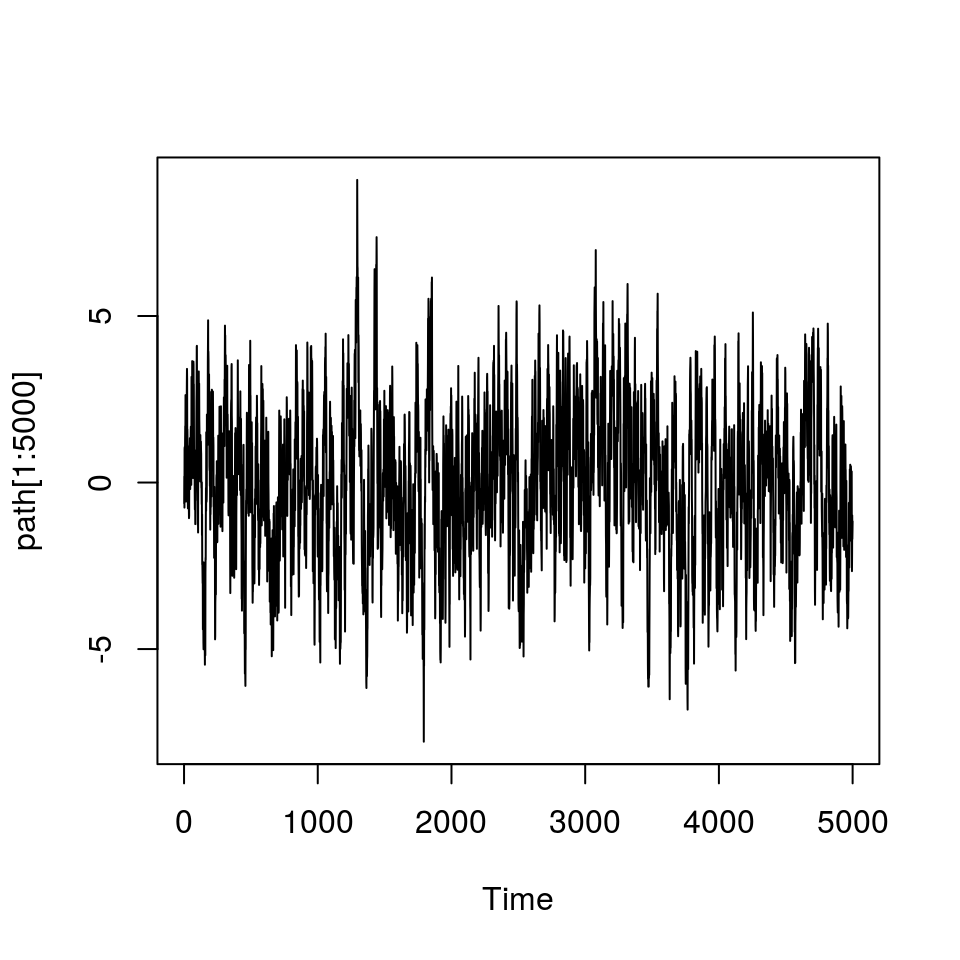

```r
ts.plot(path[1:5000])
```

```r
mc <- nimbleFunction(
   run = function(n = double(0), rho1 = double(0), rho2 = double(0)) {
       returnType(double(1))
       path <- numeric(n, init = FALSE)
       path[1] <- rnorm(1)
       path[2] <- rnorm(1)
       for(i in 3:n)
             path[i] <- rho1*path[i-1] + rho2*path[i-2] + rnorm(1)
       return(path)
})
cmc <- compileNimble(mc)
```

```
## compiling... this may take a minute. Use 'showCompilerOutput = TRUE' to see C++ compiler details.
```

```
## compilation finished.
```

```r
set.seed(1)
system.time(path <- cmc(n, rho1, rho2))
```

```
##    user  system elapsed
##    0.07    0.00    0.07
```